# Summary

mmWave radar sensors enable around the clock, remote, contactless health care monitoring without the assistance of privacy invasive cameras or equipment. The accurate and reliable performance of an IWR radar-based monitoring system enables caretakers to scale their resources more effectively with the growing desire for at-home care.

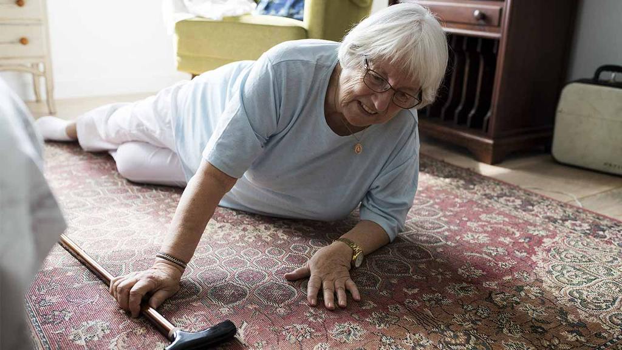

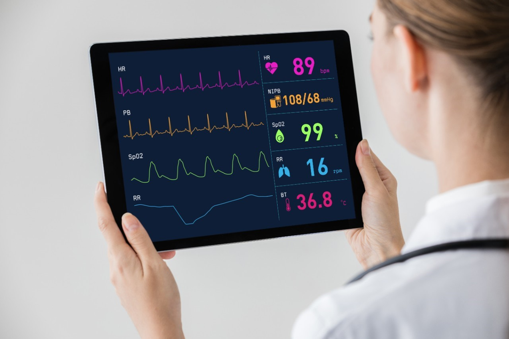

[figure not shown]

**Fall Detection**

**Vital Signs Monitoring**

**Coming Soon: Sleep Monitoring**

Recommended Devices:  
IWR6843  
IWR6843AOP  
IWRL6432

Recommended Devices:  
IWR6843  
IWR6843AOP  
IWRL6432

Recommended Devices:  
IWR6843  
IWR6843AOP  
IWRL6432

## Fall Detection

| Recommended devices | Key Functions | Key challenges overcome by radar |
| --- | --- | --- |
| IWR6843 IWR6843AOP IWRL6432 | - Presence detection - Motion detection - Posture recognition - Fall detection - Localization | - Contactless monitoring - Privacy |

### Development Resources

**Example Projects**

- 3D People Counting (IWR6843ISK, IWR6843ODS, IWR6843AOP, or IWR6843L)
- Vital Signs with People Tracking (IWR6843AOP, IWR6843ISK)

**Videos**

- [Intelligent Fall Detection using TI mmWave Radar Sensors](https://training.ti.com/intelligent-fall-detection-using-ti-mmwave-radar-sensors)
- [Contactless Patient and Elderly Care using mmWave Sensors](https://training.ti.com/contactless-patient-and-elderly-care-using-mmwave-sensors)
- [Webinar: Non-contact Patient and Elderly Monitoring with mmWave Radar](https://training.ti.com/non-contact-patient-and-elderly-monitoring-mmwave-radar-webinar)

**Experiments**

- Fall Detection

## Vital Signs Monitoring

| Recommended devices | Key Functions | Key challenges overcome by radar |
| --- | --- | --- |
| IWR6843 IWR6843AOP IWRL6432 | - Presence detection - Breath rate detection - Heart rate detection - Localization | - Accuracy - Multi-person detection - Contactless monitoring - Privacy |

### Development Resources

**Example Projects**

- Vital Signs with People Tracking (IWR6843AOP, IWR6843ISK)

**Videos**

- [Contactless Patient and Elderly Care using mmWave Sensors](https://training.ti.com/contactless-patient-and-elderly-care-using-mmwave-sensors)
- [Webinar: Non-contact Patient and Elderly Monitoring with mmWave Radar](https://training.ti.com/non-contact-patient-and-elderly-monitoring-mmwave-radar-webinar)

## Sleep Monitoring

| Recommended devices | Key Functions | Key challenges overcome by radar |
| --- | --- | --- |
| IWR6843 IWR6843AOP IWRL6432 | - Presence detection - Motion detection - People tracking | - Accuracy - Multi-person - Contactless monitoring - Privacy |

### Development Resources

Coming Soon…

## Certification

- [TI mmWave Radar Device Regulatory Compliance Guide](http://www.ti.com/lit/spracp3)
- TI mmWave Certification Database

## Third Party Resources

- [Designing TI mmWave radar made easier using our third-party ecosystem](https://e2e.ti.com/blogs_/b/industrial_strength/posts/ti-mmwave-radar-made-easy-with-our-third-party-ecosystem)
- [Browse third-party solutions and find the right third-party to meet your needs](https://www.ti.com/tool/MMWAVE-3P-SEARCH)